# Descriptive Statistic Analysis of Texas Real Estate

Pasquale Nisi

2024-02-12

We start by importing the packages we need for thin analysis:

```r
library(ggplot2)
library(dplyr)
library(moments)
library(stringr)
```

Now we are ready to import the dataset and have a glimpse of the first line:

```r
texas <- read.csv("Real Estate Texas.csv")
head(texas, 5)
```

```
##       city year month sales volume median_price listings months_inventory
## 1 Beaumont 2010     1    83 14.162       163800     1533              9.5
## 2 Beaumont 2010     2   108 17.690       138200     1586             10.0
## 3 Beaumont 2010     3   182 28.701       122400     1689             10.6
## 4 Beaumont 2010     4   200 26.819       123200     1708             10.6
## 5 Beaumont 2010     5   202 28.833       123100     1771             10.9
```

The object created after this passage is a Dataframe of 8 variables with a total of 240 observation. In particular, the variables can be described as:

- **city**: (`Character`) *Qualitative nominal variable*. Reference city;
- **year**: (`Integer`) *Categorical variable* with 5 levels. Reference year;
- **month**: (`Integer`) *Categorical variables* with 12 levels. Reference month;
- **sales**: (`Integer`) *Quantitative discrete variable*. Total number of sales;
- **volume**: (`Integer`) *Quantitative discrete variable*. Total value of Sales (in M$);
- **median_price**: (`Numeric`) *Quantitative continuous variable*. Median sale price (in $);
- **listings**: (`Numeric`) *Quantitative continuous variable*. Total number of active listings;
- **months_inventory**: (`Numeric`) *Quantitative continuous variable*. Time (in months) required to sell all listings at current rate.

We start our analysis by computing **position**,**variation** and **shape indexes** for `sales`, `volume`, `median_price`, `listings` and `months_inventory` variables.

First of all, define a new functon `v.coeff` to define variation coefficient, since there are no function included for this purpose in base R and the packages we’ve imported:

```r
v.coeff <- function(x){
  return(sd(x)/mean(x)*100)
}
```

Then can be useful to define a new Dataframe `indexes.df` where we’ll insert all indexes we needed. Let’s use `attach()` for easy access to variables in original Dataframe:

```r
attach(texas)

texas.colnames <- colnames(texas)[4:8]
indexes = c("min", "1st quartile", "median", "3rd quartile", "max", "range",
            "IQR", "mean", "std.dev", "var.coeff", "skewness", "kurtosis")
indexes.df <- data.frame(matrix(nrow = 0, ncol = length(indexes)))
colnames(indexes.df) = indexes
for (obj.name in texas.colnames) {
  obj <- pull(texas,obj.name)
  quartiles = as.numeric(quantile(obj))
  df <- texas %>%
    summarise(range=max(obj)-min(obj),
              IQR=IQR(obj),
              mean=mean(obj),
              dev.st=sd(obj),
              var.coeff=v.coeff(obj),
              skewness=skewness(obj),
              kurtosis=kurtosis(obj)-3)
  row = c(quartiles,as.numeric(df))
  indexes.df <- rbind(indexes.df, row)
}
indexes.df <- cbind(texas.colnames,indexes.df)
colnames(indexes.df) = c("variable", indexes)
indexes.df
```

```
##           variable       min 1st quartile      median 3rd quartile        max
## 1            sales    79.000     127.0000    175.5000      247.000    423.000
## 2           volume     8.166      17.6595     27.0625       40.893     83.547
## 3     median_price 73800.000  117300.0000 134500.0000   150050.000 180000.000
## 4         listings   743.000    1026.5000   1618.5000     2056.000   3296.000
## 5 months_inventory     3.400       7.8000      8.9500       10.950     14.900
##        range        IQR         mean      std.dev var.coeff    skewness
## 1    344.000   120.0000    192.29167    79.651111  41.42203  0.71810402
## 2     75.381    23.2335     31.00519    16.651447  53.70536  0.88474203
## 3 106200.000 32750.0000 132665.41667 22662.148687  17.08218 -0.36455288
## 4   2553.000  1029.5000   1738.02083   752.707756  43.30833  0.64949823
## 5     11.500     3.1500      9.19250     2.303669  25.06031  0.04097527
##     kurtosis
## 1 -0.3131764
## 2  0.1769870
## 3 -0.6229618
## 4 -0.7917900
## 5 -0.1744475
```

We can make some considerations on the outputs:

- `volume` has the highest variation coefficient, which means it has the **highest variation**;
- `volume` also has positive kurtosis, which means it is **leptokurtic**;
- All other variables have negative kurtosis, so thy are **platykurtic**;
- `median_price` has negative skewness, visible as a longer **left** tail;
- All other variables have positive skewness, visible as longer **right** tail;
- `volume` has the **highest skewness**.

Now, we can pass to analyze `city` variables. Let’s define a Distribution Frequency Table (DFT now on) for it:

```r
N = dim(texas)[1]
ni = table(city)
fi = ni/N
city_freq_distr <- cbind(ni,fi)
city_freq_distr
```

```
##                       ni   fi
## Beaumont              60 0.25
## Bryan-College Station 60 0.25
## Tyler                 60 0.25
## Wichita Falls         60 0.25
```

DFT shows a **quadrimodal distribution**, as frequencies are the same for all the cities. Since observation are uniformly distributed on the 4 categories, Gini Index for `city` is expected to be 1. Let’s define `gini.index` function and test if it is true:

```r
gini.index <- function(x){
  J <- length(table(x))
  fi2 <- (table(x)/length(x))^2
  G <- 1 - sum(fi2)
  gini <- G / ((J-1)/J)
  return(gini)
}

gini.index(city)
```

```
## [1] 1
```

The hypotesis has benn verified.

Next step is to divide `volume` variables in classes, then define DFT and Gini Index for it:

```r
volume_classes <- cut(volume,
                      breaks = seq(min(volume), max(volume),
                                   (max(volume)-min(volume))/15))

ni <- table(volume_classes)
fi <- ni/N
Ni <- cumsum(ni)
Fi <- Ni/N
volume_freq_distr <- as.data.frame(cbind(ni,fi,Ni,Fi))
volume_freq_distr
```

```
##             ni          fi  Ni        Fi
## (8.17,13.2] 24 0.100000000  24 0.1000000
## (13.2,18.2] 42 0.175000000  66 0.2750000
## (18.2,23.2] 26 0.108333333  92 0.3833333
## (23.2,28.3] 30 0.125000000 122 0.5083333
## (28.3,33.3] 27 0.112500000 149 0.6208333
## (33.3,38.3] 22 0.091666667 171 0.7125000
## (38.3,43.3] 17 0.070833333 188 0.7833333
## (43.3,48.4]  9 0.037500000 197 0.8208333
## (48.4,53.4] 17 0.070833333 214 0.8916667
## (53.4,58.4]  5 0.020833333 219 0.9125000
## (58.4,63.4]  7 0.029166667 226 0.9416667
## (63.4,68.5]  5 0.020833333 231 0.9625000
## (68.5,73.5]  4 0.016666667 235 0.9791667
## (73.5,78.5]  2 0.008333333 237 0.9875000
## (78.5,83.5]  2 0.008333333 239 0.9958333
```

```r
gini.index(volume_classes)
```

```
## [1] 0.9614769
```

We can also plot `volume_classes` frequency distribution through an histogram:

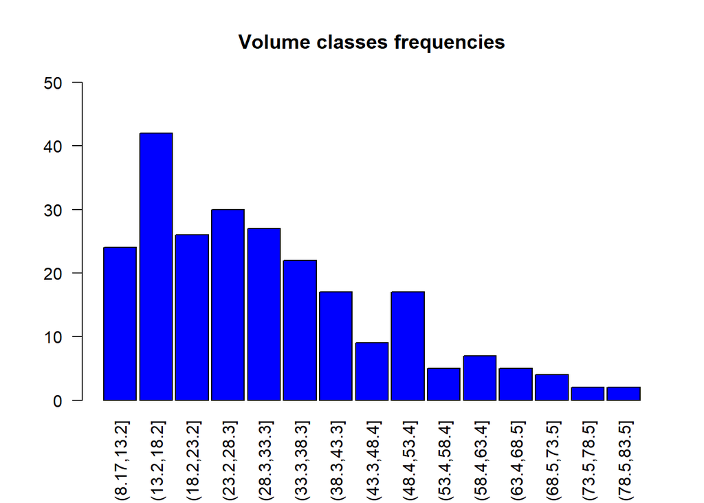

```r
barplot(volume_freq_distr$ni,
        xlab = "",
        ylab = "",
        ylim = c(0,50),
        main = "Volume classes frequencies",
        col = "blue",
        space = 0.1,
        names.arg = rownames(volume_freq_distr),
        las = 2)
```

Let’s do some probability tests. First we can investigate the probabilities of **Beaumont** occurrencies. Since the distribution is quadrimodal, we can predict a result of .25:

```r
Beaumont_ext = filter(texas, city == "Beaumont")
Beaumont_N = dim(Beaumont_ext)[1]
Beaumont_prob = Beaumont_N/N
Beaumont_prob
```

```
## [1] 0.25
```

Now we can do the same with a month, i.e. **July** which is rapresented by **7** in the `month` variable:

```r
July_ext = filter(texas, month == 7)
July_N = dim(July_ext)[1]
July_prob = July_N/N
July_prob
```

```
## [1] 0.08333333
```

Further step is combining two variables, such as `month` (i.e. **December**) and `year` (i.e. **2012**):

```r
Dec12_ext = filter(texas, year == 2012, month == 12)
Dec12_N = dim(Dec12_ext)[1]
Dec12_prob = Dec12_N/N
Dec12_prob
```

```
## [1] 0.01666667
```

To make our Dataframe more complete we can add two new variables:

- `avg_price`: average price, defined as the ratio between `volume` (in $) and `sales`;
- `sales_eff`: sales efficiency, which show the effectivness of sales offers, defined as the ratio between `sales` and `listings`.

Let’s make a new Dataframe `texas_complete` where we’ll add theme to the original Dataframe:

```r
avg_price <- (volume*1000000)/sales
sales_eff <- sales/listings
texas_complete <- cbind(texas, avg_price, sales_eff)
head(texas_complete, 5)
```

```
##       city year month sales volume median_price listings months_inventory
## 1 Beaumont 2010     1    83 14.162       163800     1533              9.5
## 2 Beaumont 2010     2   108 17.690       138200     1586             10.0
## 3 Beaumont 2010     3   182 28.701       122400     1689             10.6
## 4 Beaumont 2010     4   200 26.819       123200     1708             10.6
## 5 Beaumont 2010     5   202 28.833       123100     1771             10.9
##   avg_price  sales_eff
## 1  170626.5 0.05414220
## 2  163796.3 0.06809584
## 3  157697.8 0.10775607
## 4  134095.0 0.11709602
## 5  142737.6 0.11405985
```

For the latter variable 1 represent the highest sales efficiency, 0 the lowest; Highest sales efficiency was observed in:

- 2014
- Bryan-College Station
- Summer (June, July, August)

We can also use `dplyr` package to summarizes some info from the Dataframe. Let’s try it:

```r
texas_complete %>%
  group_by(city) %>%
  summarise(year = 2014, mean = mean(sales_eff),
            std.dev = sd(sales_eff))
```

```
## # A tibble: 4 × 4
##   city                   year   mean std.dev
##   <chr>                 <dbl>  <dbl>   <dbl>
## 1 Beaumont               2014 0.106   0.0267
## 2 Bryan-College Station  2014 0.147   0.0729
## 3 Tyler                  2014 0.0935  0.0235
## 4 Wichita Falls          2014 0.128   0.0247
```

Visualization can be very useful during statistical analysis, in particular for making comparison. We can compare `median_price` among cities using boxplot:

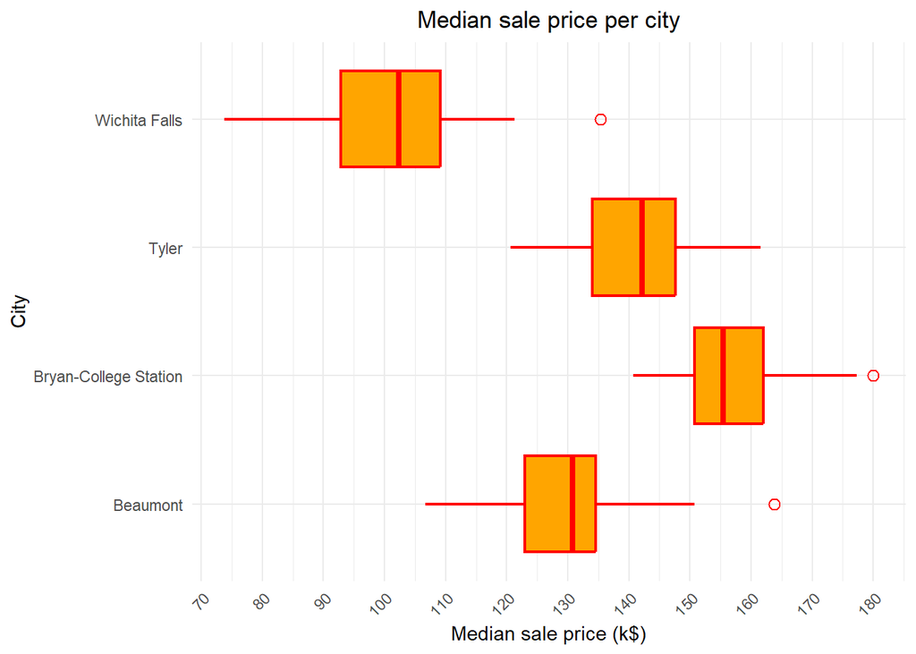

```r
cities = unique(city)

ggplot(data = texas_complete)+
  geom_boxplot(aes(x=median_price/1000,
                   y=city),
               fill = "orange",
               colour = "red",
               outlier.colour = "red",
               outlier.shape = 1,
               outlier.size = 2.5,
               linewidth = 0.75,
               outlier.stroke = 0.75,
  )+
  scale_y_discrete(labels = cities)+
  scale_x_continuous(breaks = seq(70,180,10),
                     guide = guide_axis(angle = 45))+
  labs(x="Median sale price (k$)",
       y="City",
       title = "Median sale price per city")+
  theme_minimal()+
  theme(plot.title = element_text(hjust = 0.5))
```

We can observe that **Bryan-College Station** has the highest median sale price, **Wichita Falls** the lowest. All cities have asymmetric distribution for `median_price`. **Tyler** is the only one without outliers.

We can use boxplot also to compare `volume` among cities:

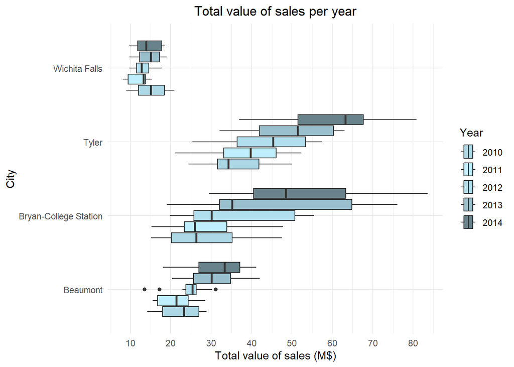

```r
ggplot(data = texas_complete)+
  geom_boxplot(aes(x=volume,
                   y=city,
                   fill=factor(year)),)+
  scale_fill_manual(
    name = "Year",
    breaks = factor(unique(year)),
    values = c("lightblue", "lightblue1", "lightblue2",
               "lightblue3", "lightblue4"),
    labels = as.character(unique(year))
  )+
  scale_y_discrete(labels=cities)+
  scale_x_continuous(breaks = seq(10,100,10))+
  labs(x="Total value of sales (M$)",
       y="City",
       title = "Total value of sales per year")+
  theme_minimal()+
  theme(plot.title = element_text(hjust = 0.5))
```

Here we can observe that:

- **Tyler** has the highest median of the total value of sales;
- **Wichita Falls** has the lowest median of the total values of sales;
- **Wichita Falls** is also almost constant, as opposed to the other cities.

Histogram can be used to compare `Volume` among cities per month. First we use a **stacked** histogram:

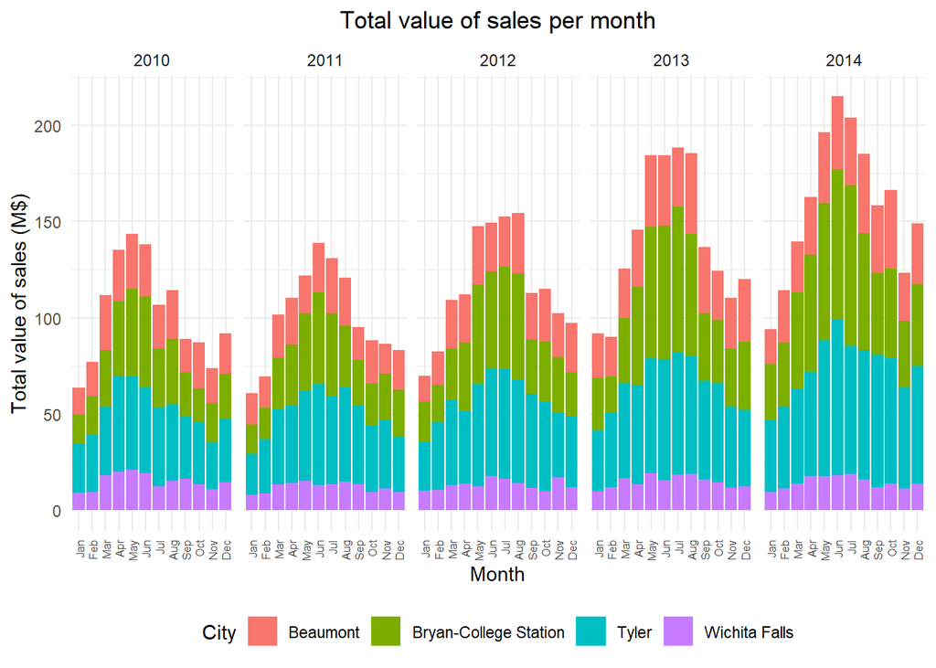

```r
ggplot(data = texas_complete)+
  geom_col(aes(x = factor(month.abb[month], levels = month.abb),
               y = volume,
               fill = city))+
  labs(x = "Month",
       y = "Total value of sales (M$)",
       title = "Total value of sales per month")+
  facet_wrap(~year,nrow = 1)+
  scale_x_discrete(guide = guide_axis(angle = 90))+
  scale_fill_discrete(name = "City",
                      labels = cities)+
  theme_minimal()+
  theme(legend.position = "bottom",
        axis.text.x = element_text(size = 6),
        plot.title = element_text(hjust = 0.5))
```

Then we can use a **normalized** histogram:

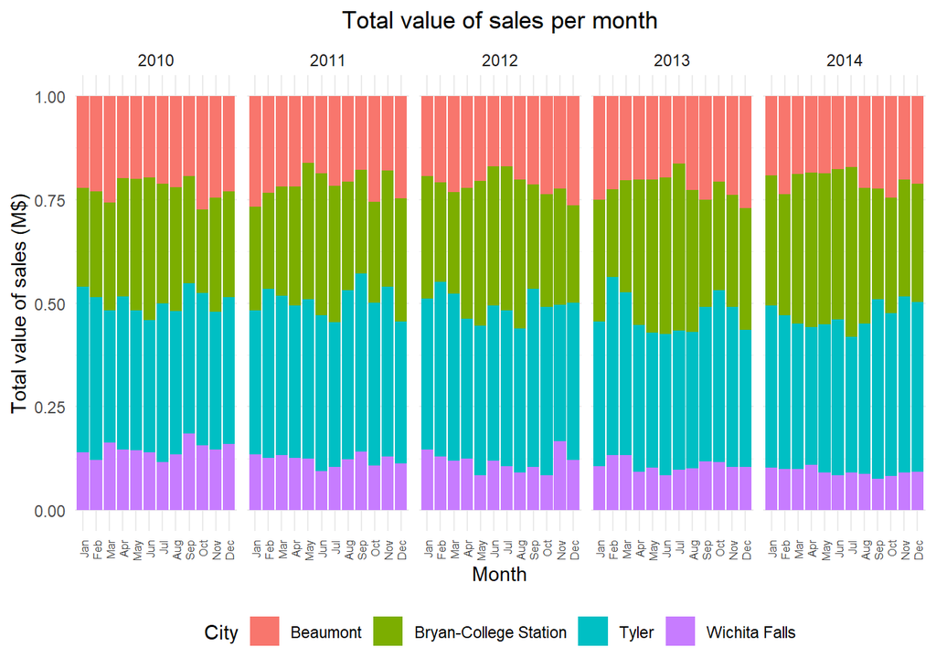

```r
ggplot(data = texas_complete)+
  geom_col(aes(x = factor(month.abb[month], levels = month.abb),
               y = volume,
               fill = city),
           position = "fill")+
  labs(x = "Month",
       y = "Total value of sales (M$)",
       title = "Total value of sales per month")+
  facet_wrap(~year,nrow = 1)+
  scale_x_discrete(guide = guide_axis(angle = 90))+
  scale_fill_discrete(name = "City",
                      labels = cities)+
  theme_minimal()+
  theme(legend.position = "bottom",
        axis.text.x = element_text(size = 6),
        plot.title = element_text(hjust = 0.5))
```

Total value of sales increases through the years, mainly by the contribution of **Tyler** total value of sales and **Bryan-College Station** median price as seen before.

Last comparison we can perform is relative to `median_price` per month among cities through year. In this case, we’ll use a line chart:

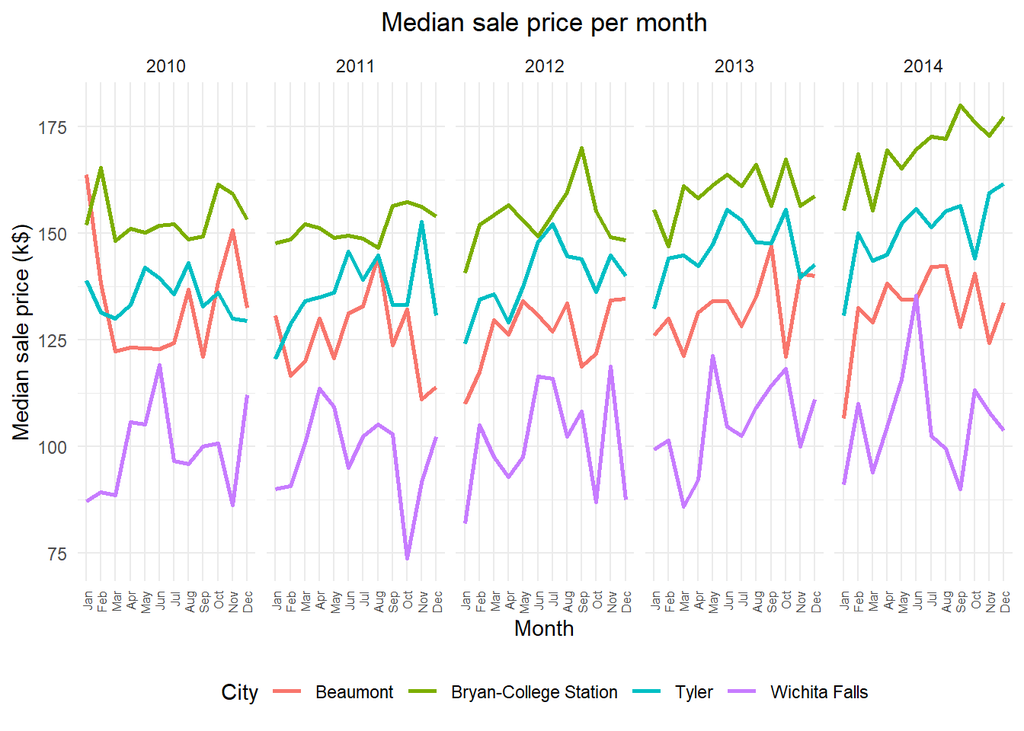

```r
ggplot(data = texas_complete)+
  geom_line(aes(x = factor(month.abb[month], levels = month.abb),
                y=median_price/1000,
                group=city,
                col=city),
            lwd=1
  )+
  facet_wrap(~year, nrow = 1)+
  scale_x_discrete(guide = guide_axis(angle = 90))+
  scale_color_discrete(name = "City")+
  labs(x="Month",
       y="Median sale price (k$)",
       title = "Median sale price per month")+
  theme_minimal()+
  theme(legend.position = "bottom",
        axis.text.x = element_text(size = 6),
        plot.title = element_text(hjust = 0.5))
```

It results that `median_price` stayed almost constant in **Beaumont** and **Wichita Falls**, while there was an increase in **Bryan-College Station** and **Tyler**, which contributes to the results seen before.

Analyzing `sales` gives the same result, but more evident:

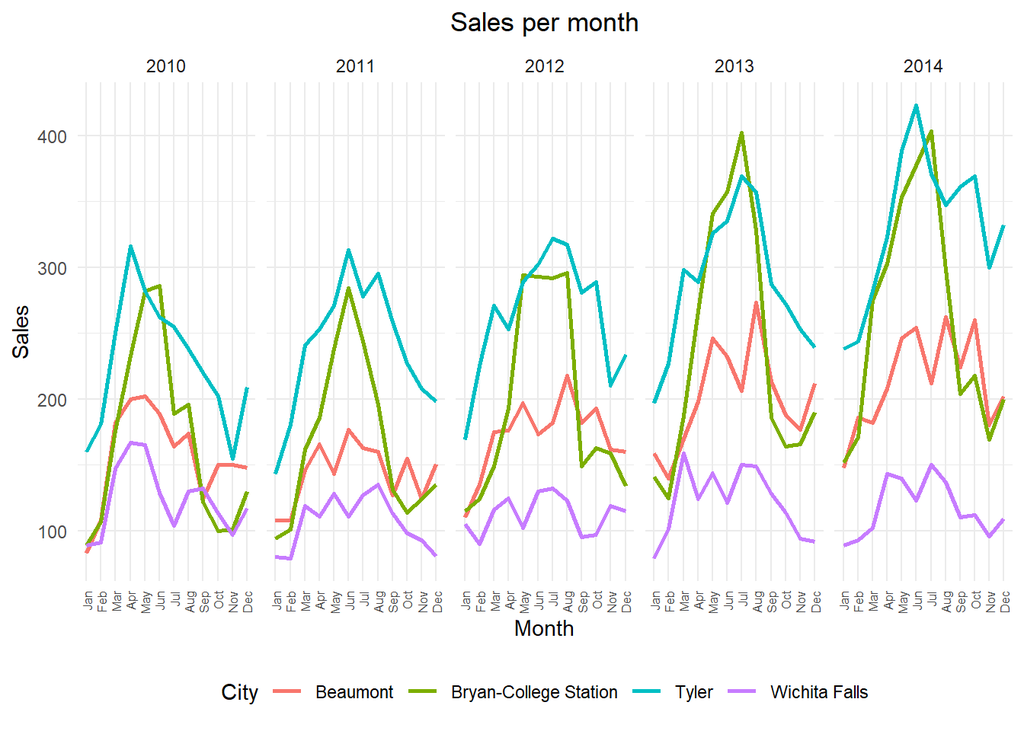

```r
ggplot(data = texas_complete)+
  geom_line(aes(x = factor(month.abb[month], levels = month.abb),
                y=sales,
                group=city,
                col=city),
            lwd=1
  )+
  facet_wrap(~year, nrow = 1)+
  scale_x_discrete(guide = guide_axis(angle = 90))+
  scale_color_discrete(name = "City")+
  labs(x="Month",
       y="Sales",
       title = "Sales per month")+
  theme_minimal()+
  theme(legend.position = "bottom",
        axis.text.x = element_text(size = 6),
        plot.title = element_text(hjust = 0.5))
```